# Project Part 2

This notebook contains the code samples found in Chapter 3, Section 5 of [Deep Learning with R](https://www.manning.com/books/deep-learning-with-r). Note that the original text features far more content, in particular further explanations and figures: in this notebook, you will only find source code and related comments.

# Data Exploration & Preparation

- Our goal in the second part of the assignment is to predict how good a (new) customer will pay back their credit card depts. In the data set application data from current customers (the first 18 attributes) together with their status (last attribute; target) are given.
- The attributes from the applications are

| Attribute Name | Explanation | Remarks |
| --- | --- | --- |
| ID | Client | number |
| CODE_GENDER | Gender |  |
| FLAG_OWN_CAR | Is there a car |  |
| FLAG_OWN_REALTY | Is there a property |  |
| CNT_CHILDREN | Number of children |  |
| AMT_INCOME_TOTAL | Annual income |  |
| NAME_INCOME_TYPE | Income category |  |
| NAME_EDUCATION_TYPE | Education level |  |
| NAME_FAMILY_STATUS | Marital status |  |
| NAME_HOUSING_TYPE | Way of living |  |
| DAYS_BIRTH | Birthday | Count backwards from current day (0), -1 means yesterday |
| DAYS_EMPLOYED | Start date of employment | Count backwards from current day(0). If positive, it means the person unemployed. |
| FLAG_MOBIL | Is there a mobile phone |  |
| FLAG_WORK_PHONE | Is there a work phone |  |
| FLAG_PHONE | Is there a phone |  |
| FLAG_EMAIL | Is there an email |  |
| OCCUPATION_TYPE | Occupation |  |
| CNT_FAM_MEMBERS | Family size |  |

- The last attribute status contains the “pay-back behavior”, i.e. when did that customer pay back their depts:
  - 0: 1-29 days past due
  - 1: 30-59 days past due
  - 2: 60-89 days overdue
  - 3: 90-119 days overdue
  - 4: 120-149 days overdue
  - 5: Overdue or bad debts, write-offs for more than 150 days
  - C: paid off that month
  - X: No loan for the month Please note: We are learning only the pay-back behavior. The decision, i.e. if we accept a customer or not, is done in another process step – not here!

# Main task

- Design your network. Why did you use a feed-forward network, or a convolutional or recursive network – and why not?
- Use k-fold validation (with k = 10) to find the best hyperparameters for your network.
- Use the average of the accuracy to evaluate the performance of your trained network.
- Find a “reasonable” good model. Argue why that model is reasonable. If you are not able to find a reasonable good model, explain what you all did to find a good model and argue why you think that’s not a good model.
- Save your trained neural network with save_model_hdf5. Also save your data sets you used for training, testing and validation.

# Some hints

- Data preprocessing is easier here; no feature engineering is needed.
- You may be able to reuse parts of the exercises we used in our examples during lectures.
- All in- and output values need to be floating numbers (or integers in exceptions) in the range of [0,1].
- Please note that a neural network expects a R matrix or vector, not data frames. Transform your data (e.g. a data frame) into a matrix with data.matrix if needed.
- There are some models which show an accuracy higher than 90% (!) for training (and test) data – after learning more than 1000 epochs.

# Important notes

- Single-label, Multiclass classification problem on page 73 in [Deep Learning with R](https://www.manning.com/books/deep-learning-with-r)
- Spaces must be removed in between ‘`{r}' and '`’, else an error with ‘’ will be produced
- K-Fold Validation on page 83ff and 94ff in [Deep Learning with R](https://www.manning.com/books/deep-learning-with-r)
- Page 110, use Last-Layer activation softmax and loss function categorical_crossentropy
- Convolutional network ausgeschlossen, weil hauptsächlich Pattern recognition/image classification
- Recursive ausgeschlossen, weil hauptsächlich für TimeSeries-Vorhersagen verwendet, oder für Vorhersagen
- Feed-Forward, weil Classification-Task

## Data import

```r
# install.packages("tidymodels")
# install.packages("themis")
library(here)
library(tidyverse)
library(ggplot2)
library(dplyr)
library(tensorflow)
library(tfdatasets)
library(tidymodels)
library(keras)
library(caret)
library(themis)
#LOAD DATA
setwd(getwd())
dataIn = "../Data/Dataset-part-2.csv"
data_in <- read.csv(dataIn,header = TRUE, sep =',')
#View(data_in)
data <- data.frame(data_in)
summary(data)
plot(data$status)
```

[output not shown]

##Cleanup

```r
# Check for duplicates
sum(duplicated(data))
# No duplicates

#Remove ID (irrelevant) and FLAG_MOBIL (always 1)
data <- data %>% select(-ID, -FLAG_MOBIL)
cols <- c("CODE_GENDER","FLAG_OWN_CAR","FLAG_OWN_REALTY","NAME_INCOME_TYPE","NAME_EDUCATION_TYPE", "NAME_FAMILY_STATUS", "NAME_HOUSING_TYPE","FLAG_WORK_PHONE","FLAG_PHONE","FLAG_EMAIL", "OCCUPATION_TYPE","status")
cols
data[cols] <- lapply(data[cols],factor)

# Replacing empty values with "Unknown"
levels(data$OCCUPATION_TYPE) <- c(levels(data$OCCUPATION_TYPE), "Unknown")
data$OCCUPATION_TYPE[is.na(data$OCCUPATION_TYPE)] <- "Unknown"

# Replacing C and X in Status
levels(data$status)[levels(data$status)=="C"] <- "6"
#data$status[data$status == "X"] <- 7
levels(data$status)[levels(data$status)=="X"] <- "7"
# #Convert factors into numericals
# data %<>% mutate_if(is.factor, as.numeric)

summary(data)
```

# Preprocessing

```r
set.seed(1)
trainIndex <- initial_split(data, prop = 0.8, strata = status)
trainingSet <- training(trainIndex)
testSet <- testing(trainIndex)
status_folds <- vfold_cv(trainingSet, v = 10, strata = status)
status_folds
```

```r
# Remove outliers (Out of 1.5x Interquartile Range) only on training set
# CNT_CHILDREN
boxplot(trainingSet$CNT_CHILDREN, horizontal=TRUE, main="CNT_CHILDREN")
Q1_Child <- quantile(trainingSet$CNT_CHILDREN, .25)
Q3_Child <- quantile(trainingSet$CNT_CHILDREN, .75)
IQR_Child <- IQR(trainingSet$CNT_CHILDREN)
# Now we keep the values within 1.5*IQR of Q1 and Q3
trainingSet <- subset(trainingSet, trainingSet$CNT_CHILDREN > (Q1_Child - 1.5*IQR_Child) & trainingSet$CNT_CHILDREN < (Q3_Child + 1.5*IQR_Child))
dim(trainingSet)

# AMT_INCOME_TOTAL
boxplot(trainingSet$AMT_INCOME_TOTAL, horizontal=TRUE, main="AMT_INCOME_TOTAL")
Q1_AIT <- quantile(trainingSet$AMT_INCOME_TOTAL, .25)
Q3_AIT <- quantile(trainingSet$AMT_INCOME_TOTAL, .75)
IQR_AIT <- IQR(trainingSet$AMT_INCOME_TOTAL)
# Now we keep the values within 1.5*IQR of Q1 and Q3
trainingSet <- subset(trainingSet, trainingSet$AMT_INCOME_TOTAL > (Q1_AIT - 1.5*IQR_AIT) & trainingSet$AMT_INCOME_TOTAL < (Q3_AIT + 1.5*IQR_AIT))
dim(trainingSet)
```

[output not shown]

```r
set.seed(5)
preprocRecipe <-
  recipe(status ~., data = data) %>%
  step_dummy(all_nominal(), -status,  one_hot = TRUE) %>%
  step_range(all_predictors(), -all_nominal(), min = 0, max = 1)%>%
  step_smote(status, over_ratio = 1) %>%
 # step_downsample(status, under_ratio = 1, skip=TRUE) %>%
 # step_smote(status, over_ratio = 1, skip=TRUE) %>%
 # step_smotenc(status, over_ratio = 1) %>%
 # step_adasyn(status, over_ratio = 1) %>%
 # step_nearmiss(status, over_ratio = 1) %>%

  step_dummy(status,  one_hot = TRUE)# %>%
```

# In this step the above defined receipt is extracted using the `prep()` function, and then use the `bake()` function to transform a set of data based on that recipe.

```r
# retain = TRUE and new_data = NULL ensures that pre-processed trainingSet is returned
trainingSet_processed <- preprocRecipe %>%
  prep(trainingSet, retain = TRUE) %>%
  bake(new_data = NULL)
testSet_processed <- preprocRecipe %>%
  prep(testSet) %>%
  bake(new_data =testSet)

#summary(trainingSet_processed)
```

## Check data

```r
# sum(trainingSet_processed$status_X0 == 1)
# sum(trainingSet_processed$status_X1 == 1)
# sum(trainingSet_processed$status_X2 == 1)
# sum(trainingSet_processed$status_X3 == 1)
# sum(trainingSet_processed$status_X4 == 1)
# sum(trainingSet_processed$status_X5 == 1)
# sum(trainingSet_processed$status_X6 == 1)
# sum(trainingSet_processed$status_X7 == 1)

# Turn data frame into data matrix
matrix_data <- trainingSet_processed %>% select(-tail(names(trainingSet_processed), 8))
matrix_targets <- trainingSet_processed %>% select(tail(names(trainingSet_processed), 8))

matrix_data_test  <- testSet_processed %>% select(-tail(names(testSet_processed), 8))
matrix_targets_test  <- testSet_processed %>% select(tail(names(testSet_processed), 8))

# summarize the class distribution
percentage <- 100-prop.table(table(data$status)) * 100

#class_counts <- table(data$status)
class_counts <- matrix_targets %>%
  summarize_all(funs(sum(. == 1)))
majority_class_count <- max(class_counts)
relative_class_counts <-  majority_class_count /class_counts

cbind(freq=table(data$status), percentage=percentage)


#Subset only 100 entries for testing
#matrix_data <- matrix_data[1:100, ]
#matrix_targets <- matrix_targets[1:100, ]
```

## Build Model

```r
#train_data <- matrix_data
train_data <- data.matrix(matrix_data)
test_data <- data.matrix(matrix_data_test)
train_targets <- data.matrix(matrix_targets)
test_targets <- data.matrix(matrix_targets_test)



# Function to build the model
build_model <- function() {
  model <- keras_model_sequential() %>%
    #layer_batch_normalization(axis = -1L, input_shape = dim(train_data)[[2]]) %>%
    layer_dense(units = 512, activation = "relu", input_shape = dim(train_data)[[2]]) %>%
    #layer_dense(units = 1024, activation = "relu") %>%
    layer_dense(units = 256, activation = "relu") %>%
    layer_dense(units = 32, activation = "relu") %>%
    #layer_dropout(0.3) %>%
    layer_dense(units = 8, activation = "softmax")

  model %>% compile(
    optimizer = optimizer_sgd(learning_rate = 0.01),
    #optimizer = optimizer_adam(),
    loss = "categorical_crossentropy",
    metrics = "categorical_accuracy"
  )

}
```

```r
#Yannick
#install.packages("kerasR")
# library(kerasR)
# model <- keras_model_sequential()
# model %>%
#          layer_dense(units = 64, activation = 'relu', dim(train_data)[[2]]) %>%
#          layer_dropout(rate = 0.2) %>%
#          # layer_dense(units = 30, activation = 'relu') %>%
#          # layer_dropout(rate = 0.3) %>%
#          layer_dense(units = 20, activation = 'relu') %>%
#          layer_dropout(rate = 0.2) %>%
#          layer_dense(units = 8, activation = 'softmax')
# summary(model)
# model %>%
#          compile(loss = 'categorical_crossentropy',
#                  optimizer = 'adam',
#                  metrics = 'accuracy')
# history <- model %>%
#          fit(train_data,
#              train_targets,
#              epochs = 1500,
#              batch_size = 1024,
#              validation_split = 0.2,
#              verbose =2,
#              class_weight = list(relative_class_counts))
# plot(history)
# model %>%
#          evaluate(test_data, test_targets)
# pred <- model %>% predict(test_data, batch_size = 32)
# y_pred = round(pred)
# # Confusion matrix
# library(caret)
# confusion_matrix <- caret::confusionMatrix(matrix(pred), matrix(test_targets))
# length(test_targets)
# table(Predicted = round(pred), Actual = test_targets)
```

## K-Fold-Validation

```r
k <- 10
indices <- sample(1:nrow(train_data))
folds <- cut(indices, breaks = k, labels = FALSE)

num_epochs <- 2500
all_acc_histories <- NULL
for (i in 1:k) {
  cat("processing fold #", i, "\n")

  val_indices <- which(folds == i, arr.ind = TRUE)
  val_data <- train_data[val_indices,] #test_data#
  val_targets <- train_targets[val_indices,] #test_targets#

  partial_train_data <- train_data[-val_indices,]
  partial_train_targets <- train_targets[-val_indices,]
  model <- build_model()

  # Train the model (in silent mode, verbose=0)
  # Batch size https://stats.stackexchange.com/questions/153531/what-is-batch-size-in-neural-network
  # One epoch = one forward pass and one backward pass of all the training examples
  # Batch size = the number of training examples in one forward/backward pass. The higher the batch size, the more memory space you'll need.
  # Number of iterations = number of passes, each pass using [batch size] number of examples. To be clear, one pass = one forward pass + one backward pass (we do not count the forward pass and backward pass as two different passes).
  # Batch size 32 much faster than 1, also the smaller the batch the less accurate the estimate of the gradient will be.
  history <- model %>% fit(
    partial_train_data, partial_train_targets,
    validation_data = list(val_data, val_targets),
    epochs = num_epochs, batch_size = 8192, verbose = 2#, class_weights = percentage
  )
  acc_history <- history$metrics$val_categorical_accuracy
  all_acc_histories <- rbind(all_acc_histories, acc_history)
}


#reticulate::py_last_error()
```

#We can then compute the average of the per-epoch ACC scores for all folds:

```r
average_acc_history <- data.frame(
  epoch = seq(1:ncol(all_acc_histories)),
  validation_acc = apply(all_acc_histories, 2, mean)
)


head(max(average_acc_history$validation_acc))
```

```
[1] 0.9398703
```

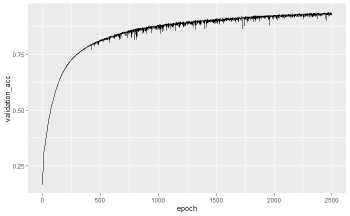

```r
library(ggplot2)
ggplot(average_acc_history, aes(x = epoch, y = validation_acc)) + geom_line()
```

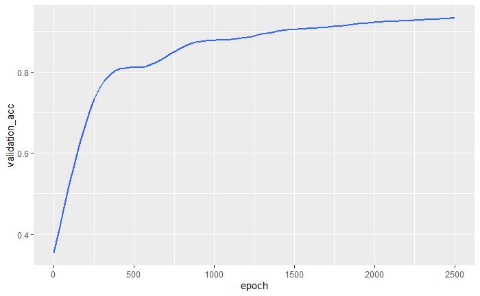

```r
#It may be a bit hard to see the plot due to scaling issues and relatively high variance. Let's use `geom_smooth()` to try to get a clearer picture:
ggplot(average_acc_history, aes(x = epoch, y = validation_acc)) + geom_smooth()
```

```r
# Evaluate on Testset
eval <- evaluate(model, test_data, test_targets, verbose = 1)
head(eval)
```

```
                loss categorical_accuracy
           0.9281037            0.7082009
```

```r
# # Save model and history, please change the name
#  write.csv(average_acc_history, "../Doc/Versuch 17 - 4 Layer - 512,256,32,8 Full Oversampling SGD 2500 Epochs/Try 17.csv", row.names=FALSE)
#  save_model_hdf5(model, "../Doc/Versuch 17 - 4 Layer - 512,256,32,8 Full Oversampling SGD 2500 Epochs/model 17.hfd5", overwrite = TRUE, include_optimizer = TRUE)
#
# # Save Training, Testing and Validation Data
#  write.csv(train_data, "../Doc/Versuch 17 - 4 Layer - 512,256,32,8 Full Oversampling SGD 2500 Epochs/train_data.csv", row.names=FALSE)
#  write.csv(test_data, "../Doc/Versuch 17 - 4 Layer - 512,256,32,8 Full Oversampling SGD 2500 Epochs/test_data.csv", row.names=FALSE)
#  write.csv(train_targets, "../Doc/Versuch 17 - 4 Layer - 512,256,32,8 Full Oversampling SGD 2500 Epochs/train_targets.csv", row.names=FALSE)
#  write.csv(test_targets, "../Doc/Versuch 17 - 4 Layer - 512,256,32,8 Full Oversampling SGD 2500 Epochs/test_targets.csv", row.names=FALSE)


# Load model
# Use model_history as precaution
# model_history <- load_model_hdf5("../Doc/Versuch 6/model 6.hfd5", custom_objects = NULL, compile = TRUE)
```